# GOV321

Day 2: Regression in R

DIGSSCORE LAB

Seminars 12-15.02

In the previous session, we focused on exploring datasets and conducting basic descriptive analyses to summarize key patterns in the data. While descriptive statistics are useful for understanding the overall characteristics of your data, they often fall short in answering questions about relationships between variables or enabling predictions.

In this session, we’ll take the next step by learning how to model and quantify the relationship between an **outcome variable** and one or more **predictor variables** using linear regression. This powerful tool allows us to make two types of predictions:

1. Predict the average value of the outcome variable for a given value of the predictor.
2. Predict the average change in the outcome variable associated with a change in the value of the predictor.

To make this concrete, we will work through the example of whether **left-right self-placement** (`lr_scale`) predicts **immigration attitudes** (`immigration`). Linear regression is a fundamental tool in data analysis and forms the basis for more advanced statistical and machine learning models. By the end of this session, you’ll have the skills to fit, interpret, and evaluate simple linear regression models using R.

### Does left-right self-placement predict immigration attitudes?

In recent decades, attitudes toward immigration have become a major political issue in Europe and beyond. A key question in political science is understanding what drives these attitudes. One factor frequently identified as influential is ideological orientation.

Ideological orientation is often conceptualized as a continuum, ranging from left-wing to right-wing. While this simplification cannot fully capture the complexity of political beliefs, it has proven remarkably predictive of a wide range of attitudes and behaviors. In this session, we will investigate whether ideological self-placement along the left-right spectrum predicts attitudes toward immigration.

The prevailing expectation is that right-wing ideology is associated with more restrictive immigration attitudes, while left-wing ideology is linked to more positive or permissive views on immigration. Based on this reasoning, the hypothesis we will be testing is:

> **Hypothesis:** Left-right self placement has no relationship with immigration attitudes.

The hypothesis is also called the null hypothesis. The alternative hypothesis is that there is a correlation between left-right self placement and immigration attitudes.

> **Alternative Hypothesis:** Those who place themselves towards the left are more likely to harbor permissive views on immigration.

## Packages

Before we proceed, we need to install and load two **packages** that will improve the presentation of results and aid in our interpretation of them. Packages are collections of functions, data, and code contributed by the broader R community to extend R’s capabilities.

In this session, we will use the following packages:

1. **`stargazer`**: To create clean, publication-ready tables for regression output.
2. **`sjPlot`**: To generate highly customizable figures for visualizing model results.

#### Installing Packages

To install a package, we use the `install.packages()` function. Once a package is installed, it is permanently added to your library and does not need to be re-installed unless updated or removed. To install the packages:

```r
# Set CRAN mirror
options(repos = c(CRAN = "https://cloud.r-project.org/"))

# Install required packages
install.packages("stargazer")
install.packages("sjPlot")
```

#### Loading Packages

To use an installed package in your current session, it must be loaded into R using the `library()` function:

```r
# Load the required packages
library(stargazer)
library(sjPlot)
```

## Loading Data

We use the same dataset as in the previous session. As a reminder, this dataset comes from a survey conducted with a representative sample of the adult Norwegian population in the spring of 2024.

```r
load("ncp_min.RData")
```

To refresh our memories about the structure of the dataset, let’s take a quick look at its variables:

```r
str(ncp_min) # Returns an overview of variables (columns) in the dataset
```

```
## 'data.frame':    10099 obs. of  9 variables:
##  $ gender        : chr  "female" "male" "male" "female" ...
##  $ education     : num  2 2 3 3 3 3 3 3 2 3 ...
##   ..- attr(*, "label")= chr "Høyeste fullførte utdanning"
##   ..- attr(*, "format.spss")= chr "F8.0"
##  $ yob           : num  1 1 1 2 1 1 1 2 2 2 ...
##   ..- attr(*, "label")= chr "Fødselsår (kort)"
##   ..- attr(*, "format.spss")= chr "F8.0"
##  $ vote_intention: chr  "sv" "ap" "ap" "venstre" ...
##  $ lr_scale      : num  2 3 4 5 1 2 3 4 8 8 ...
##   ..- attr(*, "label")= chr "Personlig plassering på politisk akse venstre-høyre"
##   ..- attr(*, "format.spss")= chr "F8.0"
##  $ immigration   : num  3 3 3 3 2 2 3 5 2 3 ...
##   ..- attr(*, "label")= chr "Fordel/ulempe at innvandrere bosetter seg i Norge"
##   ..- attr(*, "format.spss")= chr "F8.0"
##  $ eu            : num  7 6 4 5 6 4 3 6 3 1 ...
##   ..- attr(*, "label")= chr "Hvor positiv eller negativ er du til norsk medlemskap i EU? "
##   ..- attr(*, "format.spss")= chr "F8.0"
##  $ environment   : num  3 3 4 6 5 5 7 3 5 4 ...
##   ..- attr(*, "label")= chr "Enig/uenig: Økonomisk vekst bør sikres gjennom utbygging av industrien, selv om det kommer i strid med miljøinteresser."
##   ..- attr(*, "format.spss")= chr "F8.0"
##  $ economy       : num  3 2 2 1 2 1 2 4 1 2 ...
##   ..- attr(*, "label")= chr "Vurdering av: Egen økonomisk situasjon i dag"
##   ..- attr(*, "format.spss")= chr "F8.0"
```

To test the hypothesis that right-wing self-placement is associated with more restrictive immigration attitudes, we will use the `immigration` and `lr_scale` variables, which we discussed in the previous session.

The `immigration` variable captures respondents’ perceptions of whether immigration is advantageous or disadvantageous for Norway. The precise wording of the question and its response alternatives are as follows:

> **Question:**

> “In your opinion how great an advantage or disadvantage is it for Norway that immigrants come to live here?”

> **Response alternatives:**
> 1. A very great advantage
> 2. A great advantage
> 3. A slight advantage
> 4. Neither an advantage nor a disadvantage
> 5. A slight disadvantage
> 6. A great disadvantage
> 7. A very great disadvantage

Note that this variable is measured on a 7-point scale, with lower values indicating a more positive perception of immigration and higher values indicating a more negative perception.

To measure left-right ideology, we use the `lr_scale` variable. The question and response alternatives are as follows:

> **Question:**

> In politics people often talk about the “left wing” and the “right wing.” Below is a scale where 0 represents those who are on the far left politically, while 10 represents those who are on the far right.

> Where would you place yourself on such a scale?

> **Response alternatives:**

> 0 = Left wing … 10 = Right wing

This variable is measured on an 11-point scale, with lower values indicating left-wing positions and higher values indicating right-wing positions.

These two variables will allow us to examine whether ideological self-placement predicts attitudes toward immigration. Let’s now proceed to the analysis!

#### Educational example:

As we saw in the last session, our dataset is quite large and somewhat messy (as real world data typically is). For our first analysis, we’ll simplify things to make the learning process more manageable and help us build an intuition about how linear regression works. We’ll focus on a subset of 10 carefully selected respondents. These respondents were deliberately chosen—not randomly—to illustrate key concepts. (Keep in mind, this is purely for demonstration purposes—don’t do this at home!)

We subset our data by row number (each row representing an individual respondent) using the syntax introduced in the previous session. The following code selects a subset of 10 specific respondents from the dataset `ncp_min`, and store the output in a new dataset called `ncp_10`:

```r
ncp_10 <- ncp_min[c(1, 2, 7, 11, 12, 20, 21, 24, 26, 27),]
```

### Scatterplot and correlation

In the previous session, we produced a scatter plot to examine the relationship between left-right self-placement (`lr_scale`) and immigration attitudes (`immigration`) using the whole data set. However, the results were messy and challenging to interpret. Now, we’ll recreate the scatter plot using our carefully selected subset of 10 respondents. Note that we always plot the predictor on the x-axis, and the outcome variable on the y-axis. In this case, to visualize the relationship between `immigration` and `lr_scale`, we run:

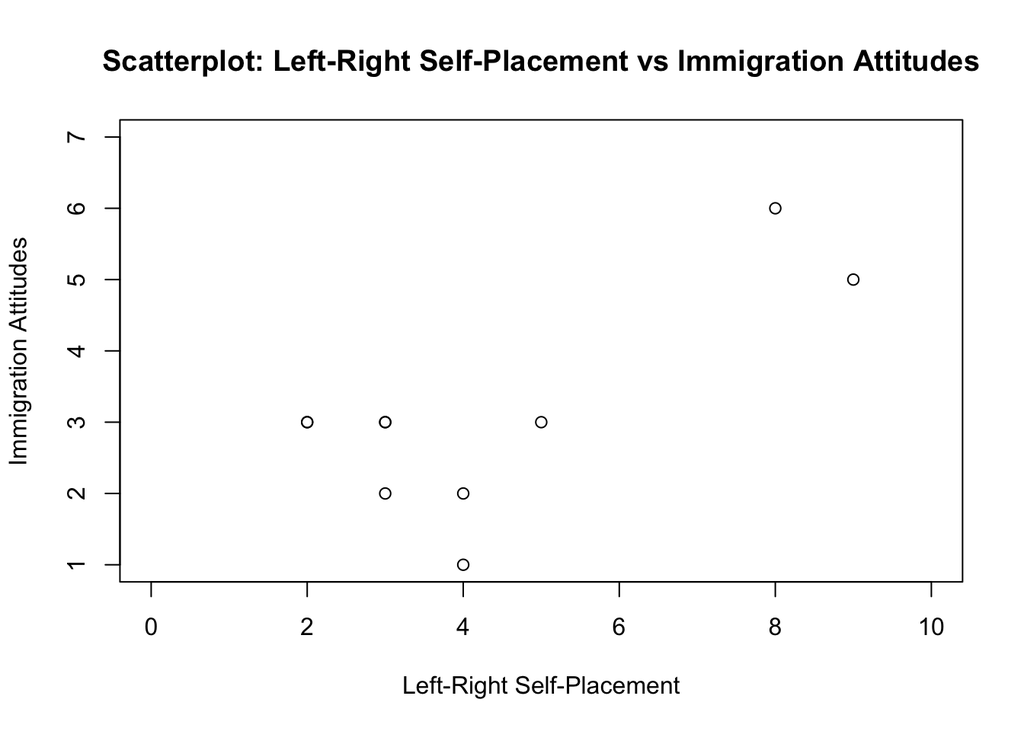

```r
# Scatter plot with jitter
plot(ncp_10$lr_scale, ncp_10$immigration,
     xlab = "Left-Right Self-Placement",
     ylab = "Immigration Attitudes",
     main = "Scatterplot: Left-Right Self-Placement vs Immigration Attitudes",
     xlim = c(0,10),
     ylim = c(1, 7))
```

The plot reveals a clear pattern, indicating a positive relationship between the two variables: higher values on the `lr_scale` variable (representing a more right-wing ideological position) are associated with higher values on the `immigration` variable (indicating more restrictive immigration attitudes).

This visual observation aligns with our hypothesis that right-wing self-placement predicts more restrictive attitudes toward immigration.

To quantify this relationship, we compute the correlation coefficient between the two variables using `cor()`:

```r
# Correlation between left-right self-placement and immigration attitudes
cor(ncp_10$lr_scale, ncp_10$immigration, use = "complete.obs")
```

```
## [1] 0.723396
```

The correlation coefficient is a statistical measure that quantifies the *strength* and *direction* of a linear relationship between two variables.

#### **From Correlation to Linear Regression**

If the two variables are related in this way, it implies that when one variable changes by a certain amount, the other variable changes, on average, by a predictable amount. For example, a shift of one point on the left-right scale (`lr_scale`) toward the right may correspond to a measurable shift in immigration attitudes (`immigration`).

## Fitting a Linear Regression Model in R

We fit the linear regression model using the `lm()` function, which stands for “linear model.”

The `lm()` function uses the formula notation `outcome ~ predictor`. The tilde (`~`) separates the outcome variable on the left-hand side from the predictor variable on the right-hand side. It specifies that the outcome variable is being modeled as a function of the predictor variable.

We save the regression model in an object named `fake_lm` (to remind ourselves we are working with manipulated data).

**NB**: keep in mind that the `lm()` function automatically excludes rows with `NA` values in any of the variables used.

```r
fake_lm <- lm(immigration ~ lr_scale, data = ncp_10)
```

### Visualizing the Fitted Regression Line

We can visualize the fitted regression line on the scatter plot from earlier using the `abline()`function. We also add grid lines using `grid()` to aid in the interpretation.

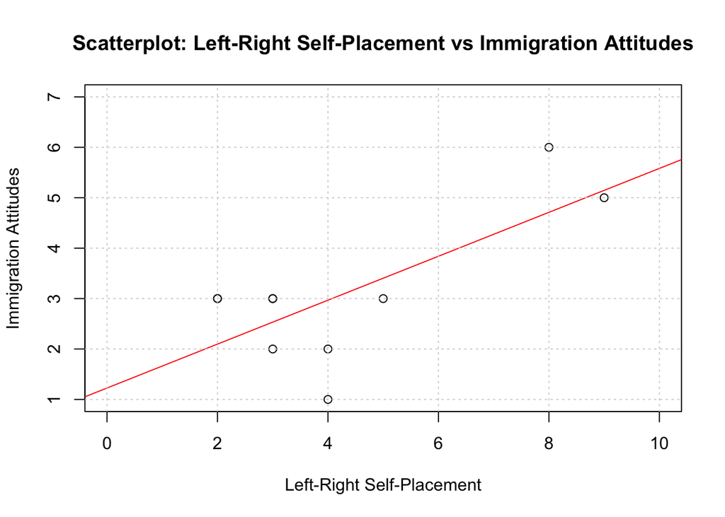

```r
# Scatter plot with jitter
plot(ncp_10$lr_scale, ncp_10$immigration,
     xlab = "Left-Right Self-Placement",
     ylab = "Immigration Attitudes",
     main = "Scatterplot: Left-Right Self-Placement vs Immigration Attitudes",
     xlim = c(0,10),
     ylim = c(1, 7))

# Adds regression line
abline(fake_lm, col = "red")

# Adds grid lines
grid()
```

Notice that none of the actual observations lie perfectly on the line. This is expected: we are not trying to perfectly match our observations but rather use them to predict unobserved values. The line represents our best estimate of where unobserved values are likely to fall, based on the observations we have.

#### Summarizing and Interpreting the Model

To view the results, we wrap the model in the `summary()` function:

```r
summary(fake_lm)
```

```
##
## Call:
## lm(formula = immigration ~ lr_scale, data = ncp_10)
##
## Residuals:
##     Min      1Q  Median      3Q     Max
## -1.9693 -0.5014  0.1593  0.7932  1.2879
##
## Coefficients:
##             Estimate Std. Error t value Pr(>|t|)
## (Intercept)   1.2265     0.7158   1.714   0.1250
## lr_scale      0.4357     0.1470   2.963   0.0181 *
## ---
## Signif. codes:  0 '***' 0.001 '**' 0.01 '*' 0.05 '.' 0.1 ' ' 1
##
## Residual standard error: 1.061 on 8 degrees of freedom
## Multiple R-squared:  0.5233, Adjusted R-squared:  0.4637
## F-statistic: 8.782 on 1 and 8 DF,  p-value: 0.01805
```

The output provides several key components for interpreting the model:

By examining these components, we can evaluate the model’s predictive power, interpret the relationship between variables, and assess the reliability of the estimates.

> **QUESTION: What is the predicted value of `immigration` for respondents who place themselves as a 0 (far left) on the `lr_scale`?**

> **QUESTION: What approximately is the predicted change in `immigration` for a one-unit increase in `lr_scale`?**

### Extending the Analysis to the Whole Dataset

Now that we’ve learned how to fit and interpret a linear regression model using a subset of data, we’ll extend the analysis to the entire dataset. Using the full dataset allows us to make more generalizable conclusions about the relationship between left-right self-placement (`lr_scale`) and immigration attitudes (`immigration`).

#### Fitting the Model to the Full Dataset

We’ll use the same syntax as before but specify the full dataset (`ncp_min`) in the `lm()` function. Since we are fitting the model with only one predictor variable (`lr_scale`), we’ll name the model `univariate_lm` to reflect this:

```r
univariate_lm <- lm(immigration ~ lr_scale, data = ncp_min)
```

#### Evaluating the Model with `summary()`

To interpret the results of the full dataset model, we use the `summary()` function:

```r
summary(univariate_lm)
```

```
##
## Call:
## lm(formula = immigration ~ lr_scale, data = ncp_min)
##
## Residuals:
##     Min      1Q  Median      3Q     Max
## -3.3533 -0.8843 -0.1697  0.8303  4.4829
##
## Coefficients:
##             Estimate Std. Error t value Pr(>|t|)
## (Intercept) 2.517081   0.027232   92.43   <2e-16 ***
## lr_scale    0.183621   0.004926   37.27   <2e-16 ***
## ---
## Signif. codes:  0 '***' 0.001 '**' 0.01 '*' 0.05 '.' 0.1 ' ' 1
##
## Residual standard error: 1.229 on 10003 degrees of freedom
##   (94 observations deleted due to missingness)
## Multiple R-squared:  0.122,  Adjusted R-squared:  0.1219
## F-statistic:  1389 on 1 and 10003 DF,  p-value: < 2.2e-16
```

### Questions:

1. What is the **Intercept** for the full dataset model? What does it represent in the context of the data?
2. What is the **slope coefficient**? How does it compare to the slope from the subset analysis?
3. How much variation in `immigration` is explained by the model (based on the R² value)? Is this higher or lower than the subset analysis? Why might this be the case?
4. Is the relationship between `lr_scale` and `immigration` statistically significant? What is the p-value for the slope coefficient?
5. Based on the regression line, predict the immigration attitudes of respondents who place themselves at `lr_scale = 5` (center) and `lr_scale = 10` (far right).

### Expanding to Multivariate Linear Regression

Now that we’ve explored univariate linear regression using a single predictor variable (`lr_scale`), we’ll expand the model to include additional predictors. Multivariate linear regression allows us to account for multiple variables simultaneously.

In this example, we’ll include the following additional predictors:

- **`yob`** (Year of Birth): Represents the respondent’s birth year and serves as a proxy for age.
- **`gender`**: A categorical variable indicating the respondent’s gender.
- **`education`**: Represents the respondent’s highest achieved education level.

These variables might also influence attitudes toward immigration, and including them will help us see how `lr_scale` predicts `immigration` while controlling for these additional factors.

## Fitting the Multivariate Model

We use the `lm()` function and expand the formula to include the additional predictors:

```r
multivariate_lm <- lm(immigration ~ lr_scale + yob + gender + education, data = ncp_min)
```

### Creating a publication ready table

The table generated by `summary()` is informative but can sometimes be overwhelming and not formatted for easy presentation. Besides, we often want tables that are polished and ready for publication (or even an MA thesis!). To create professional-looking tables, we can use the **`stargazer`** package. This package allows us to customize regression output tables and format them for use in documents.

Since we are working in an HTML document, we’ll specify `type = "html"` in the `stargazer()` function to ensure the output is properly formatted.

A useful feature of the `stargazer()` function is that it allows us to include several models in the same table. To do so, simply specify the models in the order you want them to appear. For instance, to include both our **univariate** and **multivariate** models in one table, you can write:

```r
stargazer(univariate_lm, multivariate_lm, type = "html",
          title = "Comparison of Univariate and Multivariate Models",
          align = TRUE, single.row = TRUE)
```

**Comparison of Univariate and Multivariate Models**

|  | *Dependent variable:* |  |
| --- | --- | --- |
|  | immigration |  |
|  | (1) | (2) |
| lr_scale | 0.184*** (0.005) | 0.171*** (0.005) |
| yob |  | -0.013 (0.020) |
| gendermale |  | 0.125*** (0.025) |
| education |  | -0.294*** (0.022) |
| Constant | 2.517*** (0.027) | 3.304*** (0.073) |
| Observations | 10,005 | 9,970 |
| R<sup>2</sup> | 0.122 | 0.141 |
| Adjusted R<sup>2</sup> | 0.122 | 0.140 |
| Residual Std. Error | 1.229 (df = 10003) | 1.216 (df = 9965) |
| F Statistic | 1,389.332*** (df = 1; 10003) | 407.825*** (df = 4; 9965) |
| *Note:* | p<0.1; p<0.05; p<0.01 |  |

This **side-by-side comparison** gives us a clear view of how the model changes as more variables are added. We’ll interpret it together by considering the following questions:

#### Questions:

1. What is the coefficient for `lr_scale` in the multivariate model? How does it compare to the univariate model?
2. Is `gender` a statistically significant predictor? What does the coefficient for the reference category suggest?
3. How does the Adjusted R² of the multivariate model compare to the univariate model? Does adding predictors improve the model’s fit?
4. Based on the coefficients for `education`, which education level is associated with the most restrictive immigration attitudes?
5. What is the interpretation of the coefficient for `yob`? Does it suggest older or younger individuals have more restrictive immigration attitudes?

### Coefficient plot

Another way to interpret and compare models is to visualize the coefficients using the **`sjPlot`** package. In these visualizations, the dots represent the estimated coefficients, and the whiskers represent their confidence intervals. The confidence intervals are computed based on the standard errors of the coefficients, providing a range within which the true value of the coefficient is likely to fall (with a default confidence level of 95%).

Conveniently, the `sjPlot` package also includes functionality to plot the coefficients of multiple models at once using the `plot_models()` function. If you want to plot only one model, you can use `plot_model()`. To visualize the results of our two models, simply write:

[figure not shown]

```r
plot_models(univariate_lm, multivariate_lm,
            title = "Comparison of Coefficients: Univariate vs Multivariate Models",
            axis.labels = c("Year of Birth", "Education", "Gender", "Left-Right Self-Placement"),
            legend.title = "Model",
            show.values = TRUE, show.p = TRUE)
```

### Assignment for the rest of the session:

Come up with a research question that can be answered with the data we have. The only rule is that you are not allowed to use `immigration` as the outcome variable. Formulate a hypothesis and test it using methods we have covered in this session.

Conduct the analyses in a separate rmarkdown document, where you explain (very succinctly) what your hypothesis is, and the theory behind it. Tabulate and/or plot your results.

Email me the output (tables and/or figures) so that we can go through them together at the end (*if* we have time).